# Detailed analysis of the fluid filling machine operation and detection of anomalies during the filling process

## Case study of the Renault Traffic III

[figure not shown]

#### Alix Tiran-Cappello, 13th September 2021

# Introduction

**Problematic:** Design a anomaly detection model to facilitate the identification for fluid filling failures at the end of the assembly line

**Outline:**

- Characterization the global structure of the data from the filling machine
- Design an unsupervised anomaly detection algorithm
- Apply it to the case study of the Traffic III

# Organization of the data the in df_ropit dataset

## First step of data cleaning

- Removing the corrupted lines (~95) from original dataset
- Suppressing duplicated entries revealed an high number of repeated lines
- Conversion of the timestamps to date-time format

|  | fluid | measurement | step | sourceTimestamp | pji | dataValue | body_type | driving_side | gearbox_type | hybrid_level | engine_type | time |
| --- | --- | --- | --- | --- | --- | --- | --- | --- | --- | --- | --- | --- |
| 2507786 | FRFluid | ActVacuum | StepVacuum1 | 2021-05-24 23:25:41 UTC | 1411192 | 2 | HJD | DG | BVM6 | HYB01 | K9K | 2021-05-24 23:25:41 |
| 659042 | RMFluid | ActVacuum | StepVacuum1 | 2021-05-14 19:28:52.487 UTC | 2151393 | 31 | HJD | DD | BVM6 | HYB01 | H4D | 2021-05-14 19:28:52 |
| 222419 | RMFluid | ActLoadingPressure | StepLoading | 2021-05-12 07:11:40.887 UTC | 2230423 | 185 | BJI | DG | BVM6 | HYB01 | H4D | 2021-05-12 07:11:40 |

## Example of typical filling process

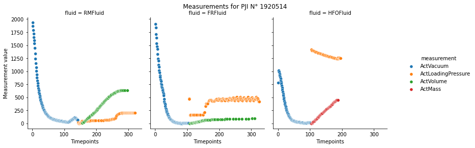

```python
names = pd.Series(df.pji.unique())
plot_all_fluid(df, names.sample(1, random_state=41).values[0]);
```

## Analysis of the diversity of car type

```python
top_cars = get_most_important_types(df, 10)
top_cars
```

|  | body_type | gearbox_type | engine_type | driving_side | hybrid_level | percentage_of_production |
| --- | --- | --- | --- | --- | --- | --- |
| 6 | BJI | BVM6 | H4D | DG | HYB01 | 23.011583 |
| 23 | HJD | BVM6 | K9K | DG | HYB01 | 21.389961 |
| 17 | HJD | BVM6 | H4D | DG | HYB01 | 14.851995 |
| 20 | HJD | BVM6 | H5H | DG | HYB01 | 6.280566 |
| 7 | BJI | CVTX | H4D | DG | HYB01 | 4.427284 |
| 29 | LJI | BVM6 | H4D | DG | HYB01 | 4.015444 |
| 16 | HJD | BVM6 | H4D | DD | HYB01 | 3.963964 |
| 13 | HJD | BVM5 | H4M | DG | HYB01 | 3.449163 |
| 19 | HJD | BVM6 | H5H | DD | HYB01 | 2.651223 |
| 21 | HJD | BVM6 | K9K | DD | HYB01 | 2.342342 |

The main most produced type of car is a subtype of the Sandero III, but only by a small margin, the other main type is the Duster II.

## Impact of the car types on the filling process

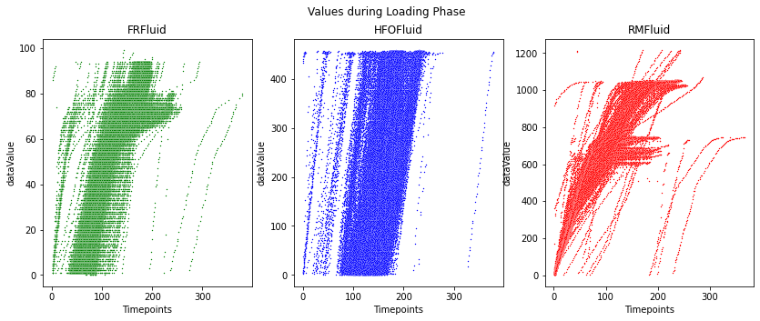

```python
temp = df[df['measurement'].isin(filling)].copy()
temp.sort_values('sourceTimestamp', inplace=True)
temp['rk'] = temp.groupby('pji').cumcount()+1

plot_fluids(temp, x='rk', y='dataValue', s=2)
plt.suptitle('Values during Loading Phase');
```

While HFOFluid filling and the car type are globally independent, the filling of FRFLuid and particularly RMFluid is extremely dependent on it, as it could be expected from the different volumes of engines.

## Analysis of the diversity within a given type

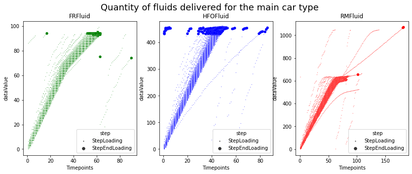

```python
cond = condition[0]
temp = df[df.measurement.isin(filling)].query(cond).copy()
temp.sort_values('sourceTimestamp', inplace=True)
temp['rk'] = temp.groupby(['pji', 'fluid']).cumcount()+1

plot_fluids(temp, x='rk', y='dataValue', size='step', sizes= (30, 1))
plt.suptitle(f'Quantity of fluids delivered for the main car type', size=18)
plt.show()
```

# Unsupervised anomaly detection algorithm

## Feature engineering

[figure not shown]

**Example of elements selected for the analysis:**

- Values at the end of each measurement
- Slope values during the process
- Interval between two data points
- Number of data points

## First exploration using a Nearest Neighbor

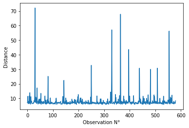

```python
near = NearestNeighbors(n_neighbors=10)
near.fit(X_train)

# distances and indexes of k-neaighbors from model outputs
distances, indexes = near.kneighbors(X_train)# plot mean of k-distances of each observation
plt.plot(distances.mean(axis =1))
plt.ylabel('Distance')
plt.xlabel('Observation N°');
```

The algorithm is however not directly adapted for the prediction on unseen data

## Detection using Local Outlier Factor

```python
lof = LocalOutlierFactor(n_neighbors=20, contamination='auto', novelty=True)
lof.fit(X_train)

detect = pd.DataFrame(lof.predict(X_test))
detect.columns = ['anomaly']
detect['score'] = lof.score_samples(X_test)
detect.index = test.index
detect = detect[detect.anomaly == -1].sort_values('score')
detect
```

| pji | anomaly | score |
| --- | --- | --- |
| 2320061 | -1 | -36.936787 |
| 2730079 | -1 | -15.499131 |
| 931371 | -1 | -9.501739 |
| 2440056 | -1 | -6.515402 |
| 640060 | -1 | -6.235750 |
| 950084 | -1 | -2.734108 |
| 1050767 | -1 | -2.049279 |
| 2420082 | -1 | -2.048725 |
| 1620268 | -1 | -1.864474 |
| 1521062 | -1 | -1.527026 |

**Note:** This algorithm was preferred compared to an Isolation Forest (fewer detections) or a One Class SVM (Too many detections)

## Typical anomaly example

Missing data during one of the phases or for one of the fluid:

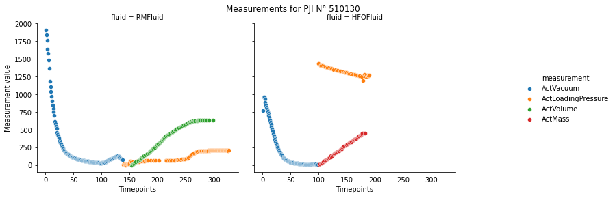

```python
plot_all_fluid(df, bad_pji[0]);
```

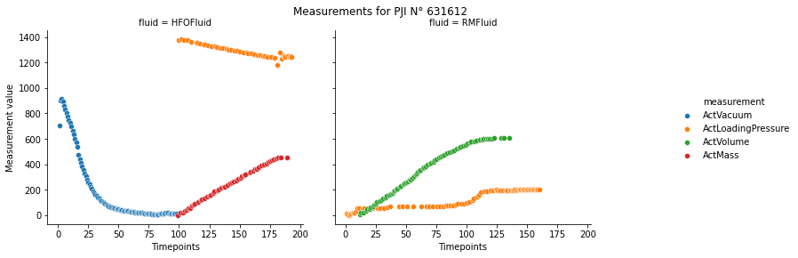

```python
plot_all_fluid(df, bad_pji[2]);
```

Examples detected by the LOF algorithm:

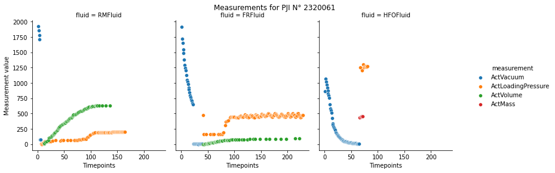

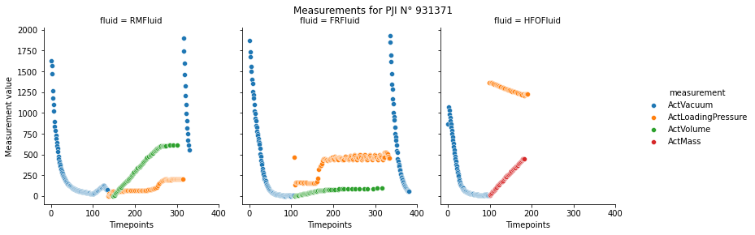

# Case study of the Renault Traffic III

## Training on the train_df_lha.csv

Small adaptations were required, two elements were removed from the detection algorithm:

- HFOFluid is not used for this type of car
- ActVacuum Phase was intentionally left out, since in the training dataset, it is missing for a large part of the samples

**Example of filling process for one of the fluid in the training set:**

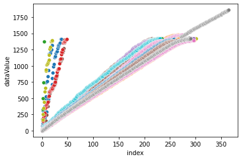

```python
for num in working_df.pji.unique():
    plot_selective_fluid(df,num, 'RMFluid', 'ActVolume')
```

```python
anomaly.X_test
```

[output not shown]

**Examples of anomalies in the train set:**

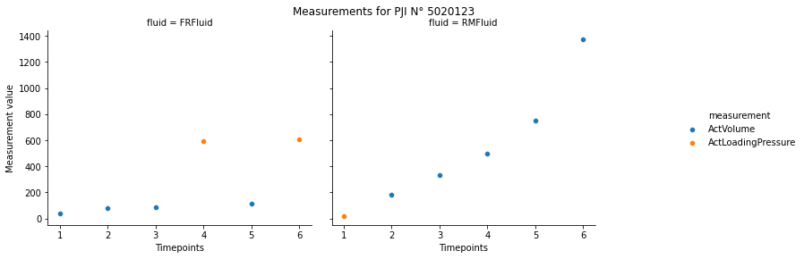

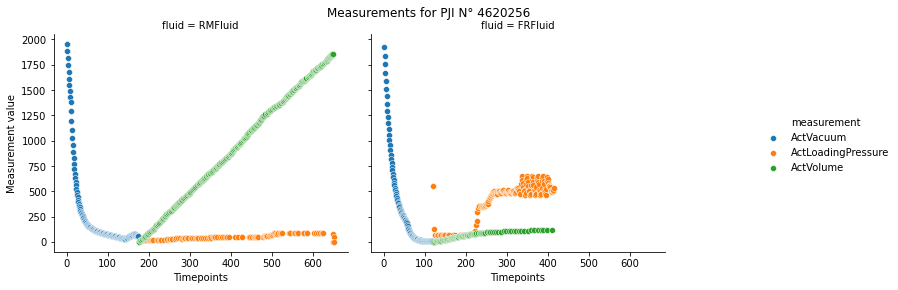

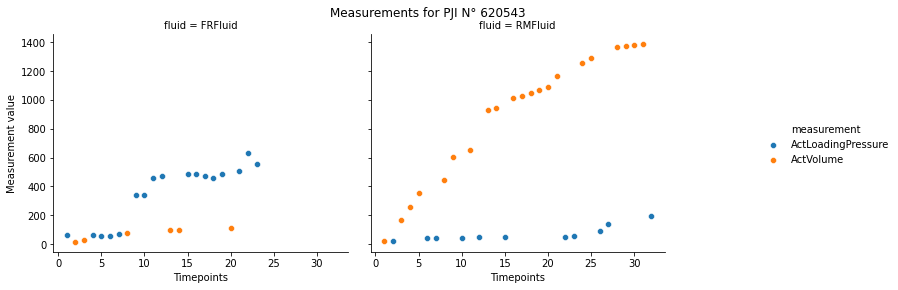

## Anomaly search in the inference dataset

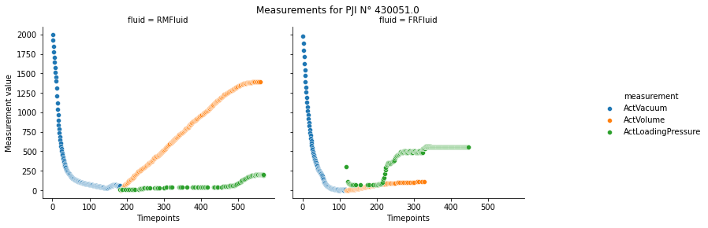

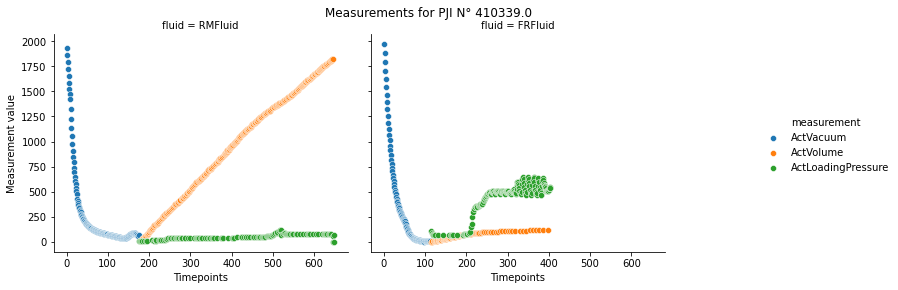

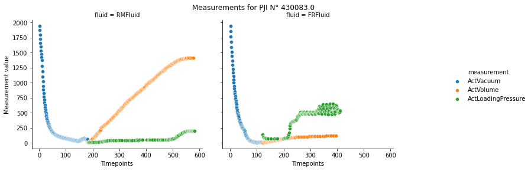

The current model does not detect anything particular in the test dataset beyond a few sparse anomalies, and if there is a specific pattern to identify this algorithm would have missed it.

## Post analysis of the test dataset

**Do you notice something happening starting on Jan-29?**

**How would you react to this in a production environment?**

Increasing the `contamination` parameter increased the number of detections, however it is difficult to highlight a particular trend.

Changing the model to an isolation forest yield similar results

# Conclusion

- Current model classifies about 10% of the production as an anomaly
- Based on production returns, it is possible to adjust the sensibility of the detection
- Perspective to improve the model by looking at a sequence of consecutive pji and estimate a percentage of failures to account for some of the context information.